# Task To Be Performed

Using the same transaction dataset, identify the annual salary for each customer

Explore correlations between annual salary and various customer attributes (e.g. age). These attributes could be those that are readily available in the data (e.g. age) or those that you construct or derive yourself (e.g. those relating to purchasing behaviour). Visualise any interesting correlations using a scatter plot.

Build a simple regression model to predict the annual salary for each customer using the attributes you identified above

How accurate is your model? Should ANZ use it to segment customers (for whom it does not have this data) into income brackets for reporting purposes?

For a challenge: build a decision-tree based model to predict salary. Does it perform better? How would you accurately test the performance of this model?

# Importing the Dependencies

```python
import pandas as pd
import numpy as np
import seaborn as sns
import matplotlib.pyplot as plt
from sklearn.linear_model import LinearRegression
from sklearn.tree import DecisionTreeRegressor
from sklearn.cluster import KMeans
from sklearn.preprocessing import PolynomialFeatures
from sklearn.model_selection import train_test_split
from sklearn.metrics import mean_squared_error, r2_score
```

```python
#Loading the dataset
data=pd.read_excel("C:/Users/Rahul Gupta/Documents/Dataset/ANZ synthesised transaction dataset.xlsx")
data.head()
```

|  | status | card_present_flag | bpay_biller_code | account | currency | long_lat | txn_description | merchant_id | merchant_code | first_name | ... | age | merchant_suburb | merchant_state | extraction | amount | transaction_id | country | customer_id | merchant_long_lat | movement |
| --- | --- | --- | --- | --- | --- | --- | --- | --- | --- | --- | --- | --- | --- | --- | --- | --- | --- | --- | --- | --- | --- |
| 0 | authorized | 1.0 | NaN | ACC-1598451071 | AUD | 153.41 -27.95 | POS | 81c48296-73be-44a7-befa-d053f48ce7cd | NaN | Diana | ... | 26 | Ashmore | QLD | 2018-08-01T01:01:15.000+0000 | 16.25 | a623070bfead4541a6b0fff8a09e706c | Australia | CUS-2487424745 | 153.38 -27.99 | debit |
| 1 | authorized | 0.0 | NaN | ACC-1598451071 | AUD | 153.41 -27.95 | SALES-POS | 830a451c-316e-4a6a-bf25-e37caedca49e | NaN | Diana | ... | 26 | Sydney | NSW | 2018-08-01T01:13:45.000+0000 | 14.19 | 13270a2a902145da9db4c951e04b51b9 | Australia | CUS-2487424745 | 151.21 -33.87 | debit |
| 2 | authorized | 1.0 | NaN | ACC-1222300524 | AUD | 151.23 -33.94 | POS | 835c231d-8cdf-4e96-859d-e9d571760cf0 | NaN | Michael | ... | 38 | Sydney | NSW | 2018-08-01T01:26:15.000+0000 | 6.42 | feb79e7ecd7048a5a36ec889d1a94270 | Australia | CUS-2142601169 | 151.21 -33.87 | debit |
| 3 | authorized | 1.0 | NaN | ACC-1037050564 | AUD | 153.10 -27.66 | SALES-POS | 48514682-c78a-4a88-b0da-2d6302e64673 | NaN | Rhonda | ... | 40 | Buderim | QLD | 2018-08-01T01:38:45.000+0000 | 40.90 | 2698170da3704fd981b15e64a006079e | Australia | CUS-1614226872 | 153.05 -26.68 | debit |
| 4 | authorized | 1.0 | NaN | ACC-1598451071 | AUD | 153.41 -27.95 | SALES-POS | b4e02c10-0852-4273-b8fd-7b3395e32eb0 | NaN | Diana | ... | 26 | Mermaid Beach | QLD | 2018-08-01T01:51:15.000+0000 | 3.25 | 329adf79878c4cf0aeb4188b4691c266 | Australia | CUS-2487424745 | 153.44 -28.06 | debit |

5 rows × 23 columns

```python
data.columns
```

```
Index(['status', 'card_present_flag', 'bpay_biller_code', 'account',
       'currency', 'long_lat', 'txn_description', 'merchant_id',
       'merchant_code', 'first_name', 'balance', 'date', 'gender', 'age',
       'merchant_suburb', 'merchant_state', 'extraction', 'amount',
       'transaction_id', 'country', 'customer_id', 'merchant_long_lat',
       'movement'],
      dtype='object')
```

```python
data.shape
```

```
(12043, 23)
```

```python
data.info()
```

```
<class 'pandas.core.frame.DataFrame'>
RangeIndex: 12043 entries, 0 to 12042
Data columns (total 23 columns):
 #   Column             Non-Null Count  Dtype
---  ------             --------------  -----
 0   status             12043 non-null  object
 1   card_present_flag  7717 non-null   float64
 2   bpay_biller_code   885 non-null    object
 3   account            12043 non-null  object
 4   currency           12043 non-null  object
 5   long_lat           12043 non-null  object
 6   txn_description    12043 non-null  object
 7   merchant_id        7717 non-null   object
 8   merchant_code      883 non-null    float64
 9   first_name         12043 non-null  object
 10  balance            12043 non-null  float64
 11  date               12043 non-null  datetime64[ns]
 12  gender             12043 non-null  object
 13  age                12043 non-null  int64
 14  merchant_suburb    7717 non-null   object
 15  merchant_state     7717 non-null   object
 16  extraction         12043 non-null  object
 17  amount             12043 non-null  float64
 18  transaction_id     12043 non-null  object
 19  country            12043 non-null  object
 20  customer_id        12043 non-null  object
 21  merchant_long_lat  7717 non-null   object
 22  movement           12043 non-null  object
dtypes: datetime64[ns](1), float64(4), int64(1), object(17)
memory usage: 2.1+ MB
```

```python
# selecting important featuers
df=data[["customer_id","age","txn_description","balance","amount"]]
df.head()
```

|  | customer_id | age | txn_description | balance | amount |
| --- | --- | --- | --- | --- | --- |
| 0 | CUS-2487424745 | 26 | POS | 35.39 | 16.25 |
| 1 | CUS-2487424745 | 26 | SALES-POS | 21.20 | 14.19 |
| 2 | CUS-2142601169 | 38 | POS | 5.71 | 6.42 |
| 3 | CUS-1614226872 | 40 | SALES-POS | 2117.22 | 40.90 |
| 4 | CUS-2487424745 | 26 | SALES-POS | 17.95 | 3.25 |

```python
print(df['txn_description'].unique())
```

```
['POS' 'SALES-POS' 'PAYMENT' 'INTER BANK' 'PAY/SALARY' 'PHONE BANK']
```

```python
plot_data= df.groupby(["customer_id"]).mean().reset_index()
plot_data.head()
```

|  | customer_id | age | balance | amount |
| --- | --- | --- | --- | --- |
| 0 | CUS-1005756958 | 53 | 2275.852055 | 222.862603 |
| 1 | CUS-1117979751 | 21 | 9829.929000 | 339.843700 |
| 2 | CUS-1140341822 | 28 | 5699.212250 | 212.632500 |
| 3 | CUS-1147642491 | 34 | 9032.841186 | 245.600169 |
| 4 | CUS-1196156254 | 34 | 22272.433755 | 147.145796 |

# Finding out the mean salary of each customer

```python
salary=df[df["txn_description"]=="PAY/SALARY"].groupby("customer_id").mean().reset_index()
salary=salary[["customer_id","amount"]]
salary=salary.rename(columns = {'amount':'salary'})
```

```python
salary.head()
```

|  | customer_id | salary |
| --- | --- | --- |
| 0 | CUS-1005756958 | 970.47 |
| 1 | CUS-1117979751 | 3578.65 |
| 2 | CUS-1140341822 | 1916.51 |
| 3 | CUS-1147642491 | 1711.39 |
| 4 | CUS-1196156254 | 3903.73 |

# Create some plots to analyze relation between existing data

```python
plot_data=pd.merge(plot_data, salary, on="customer_id")
plot_data.head()
```

|  | customer_id | age | balance | amount | salary |
| --- | --- | --- | --- | --- | --- |
| 0 | CUS-1005756958 | 53 | 2275.852055 | 222.862603 | 970.47 |
| 1 | CUS-1117979751 | 21 | 9829.929000 | 339.843700 | 3578.65 |
| 2 | CUS-1140341822 | 28 | 5699.212250 | 212.632500 | 1916.51 |
| 3 | CUS-1147642491 | 34 | 9032.841186 | 245.600169 | 1711.39 |
| 4 | CUS-1196156254 | 34 | 22272.433755 | 147.145796 | 3903.73 |

# Salary v/s Age

[output not shown]

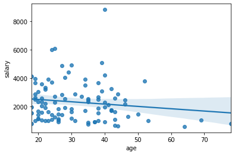

```python
sns.regplot("age","salary",data=plot_data)
```

- People usually have lower average salary and there is only one individual with high salary which is a suspected outlier.

# Salary v/s Account Balance

[output not shown]

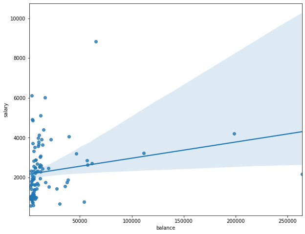

```python
plt.figure(figsize=(10,8))
sns.regplot("balance","salary",data=plot_data)
```

- People have low balance with low average salary.

# Salary v/s Transaction Amount

[output not shown]

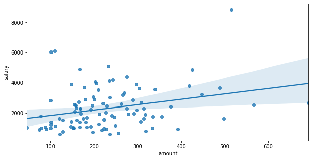

```python
plt.figure(figsize=(10, 5))
sns.regplot("amount", "salary",data=plot_data)
```

- People usually have low salary and hence the transaction amount is low. But there are some individuals who have transacted high amount instead of low salary.

# Data Preparation

Mean POS (Point of Sale) for each customer

```python
# POS indicates spending behavior of customer
pos=df[df["txn_description"]==("POS"or"SALES-POS")].groupby("customer_id").mean().reset_index()
pos=pos[["customer_id","amount"]]
pos=pos.rename(columns = {'amount':'pos'})
```

```python
pos.head()
```

|  | customer_id | pos |
| --- | --- | --- |
| 0 | CUS-1005756958 | 28.769615 |
| 1 | CUS-1117979751 | 23.321923 |
| 2 | CUS-1140341822 | 34.781282 |
| 3 | CUS-1147642491 | 54.271316 |
| 4 | CUS-1196156254 | 31.157432 |

Mean payment made by the customer

```python
len(pos)
```

```
100
```

```python
payment=df[df["txn_description"]=="PAYMENT"].groupby("customer_id").mean().reset_index()
payment=payment[["customer_id","amount"]]
payment=payment.rename(columns = {'amount':'payment'})
```

```python
payment.head()
```

|  | customer_id | payment |
| --- | --- | --- |
| 0 | CUS-1005756958 | 144.000000 |
| 1 | CUS-1117979751 | 98.925000 |
| 2 | CUS-1140341822 | 142.000000 |
| 3 | CUS-1147642491 | 96.185185 |
| 4 | CUS-1196156254 | 43.100000 |

Mean Inter-bank transfer by each customer

```python
len(payment)
```

```
100
```

```python
interbank=df[df["txn_description"]=='INTER BANK'].groupby("customer_id").mean().reset_index()
interbank=interbank[["customer_id","amount"]]
interbank=interbank.rename(columns = {'amount':'interbank'})
```

```python
interbank.head()
```

|  | customer_id | interbank |
| --- | --- | --- |
| 0 | CUS-1117979751 | 1001.0000 |
| 1 | CUS-1140341822 | 90.0000 |
| 2 | CUS-1147642491 | 125.0000 |
| 3 | CUS-1196156254 | 153.4000 |
| 4 | CUS-1271030853 | 76.1875 |

```python
len(interbank)
```

```
68
```

Mean phone transaction made by the customer

```python
#Banking via phone/online pay

phonebank=df[df["txn_description"]=='PHONE BANK'].groupby("customer_id").mean().reset_index()
phonebank=phonebank[["customer_id","amount"]]
phonebank=phonebank.rename(columns = {'amount':'phonebank'})
```

```python
phonebank.head()
```

|  | customer_id | phonebank |
| --- | --- | --- |
| 0 | CUS-1005756958 | 182.0 |
| 1 | CUS-1646183815 | 150.0 |
| 2 | CUS-1896554896 | 1916.0 |
| 3 | CUS-2155701614 | 82.0 |
| 4 | CUS-2348881191 | 1629.0 |

```python
len(phonebank)
```

```
16
```

Merging Relevant Dataframes

```python
customer=df.groupby("customer_id").mean().reset_index()
customer=customer[["customer_id","age","balance"]]
customer.head()
```

|  | customer_id | age | balance |
| --- | --- | --- | --- |
| 0 | CUS-1005756958 | 53 | 2275.852055 |
| 1 | CUS-1117979751 | 21 | 9829.929000 |
| 2 | CUS-1140341822 | 28 | 5699.212250 |
| 3 | CUS-1147642491 | 34 | 9032.841186 |
| 4 | CUS-1196156254 | 34 | 22272.433755 |

```python
df1=pd.merge(customer,payment,on='customer_id')
df1=pd.merge(df1,pos,on="customer_id")
df1=pd.merge(df1,salary,on="customer_id")
```

```python
df1.head()
```

|  | customer_id | age | balance | payment | pos | salary |
| --- | --- | --- | --- | --- | --- | --- |
| 0 | CUS-1005756958 | 53 | 2275.852055 | 144.000000 | 28.769615 | 970.47 |
| 1 | CUS-1117979751 | 21 | 9829.929000 | 98.925000 | 23.321923 | 3578.65 |
| 2 | CUS-1140341822 | 28 | 5699.212250 | 142.000000 | 34.781282 | 1916.51 |
| 3 | CUS-1147642491 | 34 | 9032.841186 | 96.185185 | 54.271316 | 1711.39 |
| 4 | CUS-1196156254 | 34 | 22272.433755 | 43.100000 | 31.157432 | 3903.73 |

Feature Selection for New Features

Payment v/s Salary

[output not shown]

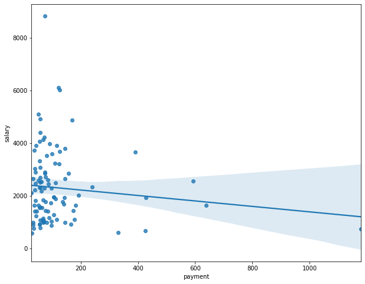

```python
plt.figure(figsize=(10,8))
sns.regplot("payment","salary",data=df1)
```

- People usually have low salary hence their payment amount is low but there is some individuals who made higher payment instead of low salary.

Salary v/s Point of Sale

[output not shown]

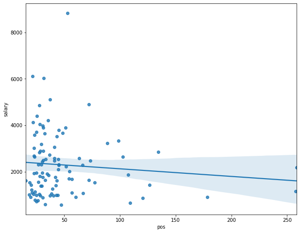

```python
plt.figure(figsize=(10,8))
sns.regplot("pos","salary",data=df1)
```

- Most of the point of sales are less than 70 with individuals having low salary.

# Model Building & Predictive Analytics

# Linear Regression

```python
X=df1.drop(columns=['customer_id','salary'],axis=1)
y=df1['salary'].values
```

```python
X_train,X_test,y_train,y_test=train_test_split(X,y,test_size=0.2,random_state=14)
```

```python
lr=LinearRegression()
lr.fit(X_train,y_train)
lr_pred=lr.predict(X_test)
print("Coefficient of Determination: ",metrics.r2_score(y_test,lr_pred))
```

[output not shown]

- Linear regression model has very low coefficient of determination and hence the model is not so accurate.
- ANZ should not use it to segment customers (for whom it does not have this data) into income brackets for reporting purposes.

# Decision Tree Regression

```python
dt=DecisionTreeRegressor()
dt.fit(X_train,y_train)
dt_pred=dt.predict(X_test)
print("Accuracy Score={}".format(r2_score(y_test,dt_pred)))
```

```
Accuracy Score=0.0639405488605439
```

- Decision-tree based model too does not performing better.